<< voltar ao site

# Visualização dos dados dos boletins da SESAB para os casos de COVID-19 no Território de Identidade Bacia do Jacuípe - BA

```
Dados atualizados em 12-08-2020 às 18:15
```

Este documento tem o objetivo de analisar e apresentar de forma intuitiva os dados extraídos dos boletins diários da **SESAB** (Secretaria de Saúde da Bahia), garantindo o máximo de transparência nos dados sem nenhum tipo de viés nessa análise.

A extração desses dados é feita de forma automática e por isso, em alguns momentos, precisam ser confrontados com os dados diários dos boletins. As tabelas dos boletins são transformadas em bases de dados que são pré-processadas (limpeza, criação de atributos, etc) para serem então utilizadas na geração das visualizações dessa página.

## Sumário

- Informações sobre os municípios da Bacia do Jacuípe
- Dados sobre a COVID-19 no território
  - Distribuição dos casos de COVID-19 no território
  - Novos casos registrados no último boletim da SESAB
  - Distribuição geográfica da COVID-19 no território
- Dados históricos da COVID-19 na Bacia do Jacuípe
- Dados históricos da COVID-19 por cidade

## 1. Informações Gerais

Topo da página

| Municípios | População |
| --- | --- |
| Ipirá | 59595 |
| Riachão do Jacuípe | 33436 |
| Capim Grosso | 30662 |
| Baixa Grande | 20468 |
| Mairi | 18676 |
| Serra Preta | 14878 |
| Várzea da Roça | 14104 |
| Pé de Serra | 13578 |
| Capela do Alto Alegre | 11637 |
| São José do Jacuípe | 10462 |
| Pintadas | 10437 |
| Várzea do Poço | 9170 |
| Quixabeira | 8972 |
| Nova Fátima | 7812 |
| Gavião | 4463 |

**Fonte**: Boletim COVID-19 SESAB

## 2. Dados sobre a COVID-19 confirmados pela SESAB para a Bacia do Jacuípe

Topo da página

```
A Bacia do Jacuípe possui 2210 casos confirmados pela SESAB até a data 12-08-2020
```

### 2.1 Distribuição dos casos de COVID-19

Topo da página

|  | Município | Total de casos confirmados | Porcentagem |
| --- | --- | --- | --- |
| 1 | Capim Grosso | 628 | 28.42% |
| 2 | Riachão do Jacuípe | 332 | 15.02% |
| 3 | Ipirá | 253 | 11.45% |
| 4 | Várzea da Roça | 192 | 8.69% |
| 5 | Serra Preta | 186 | 8.42% |
| 6 | Capela do Alto Alegre | 132 | 5.97% |
| 7 | Mairi | 122 | 5.52% |
| 8 | Pintadas | 119 | 5.38% |
| 9 | Nova Fátima | 59 | 2.67% |
| 10 | Pé de Serra | 58 | 2.62% |
| 11 | São José do Jacuípe | 50 | 2.26% |
| 12 | Quixabeira | 48 | 2.17% |
| 13 | Várzea do Poço | 15 | 0.68% |
| 14 | Baixa Grande | 14 | 0.63% |
| 15 | Gavião | 2 | 0.09% |
| 16 | TOTAL | 2210 | 100.0% |

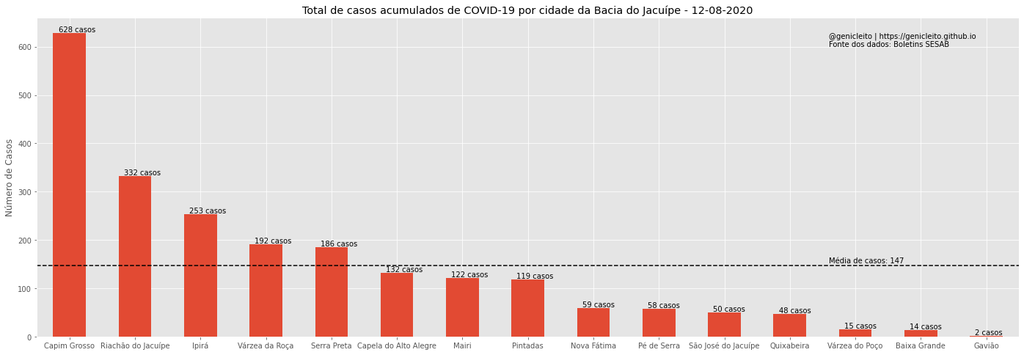

**Fonte**: Boletim COVID-19 SESAB

### 2.2 Novos casos registrados no atual boletim da SESAB

Topo da página

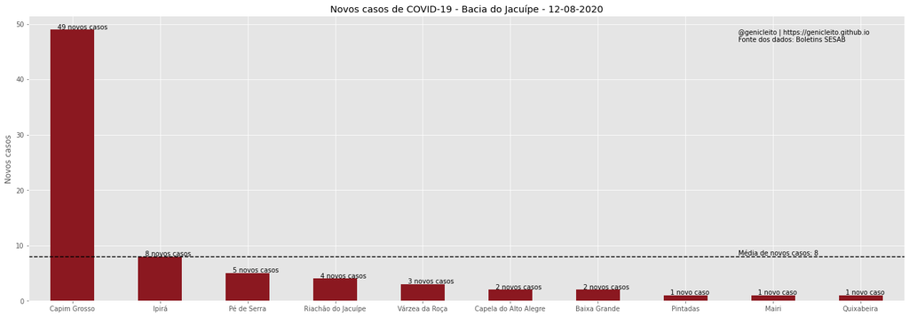

### 2.3 Dados geográficos da COVID-19 no território

Topo da página

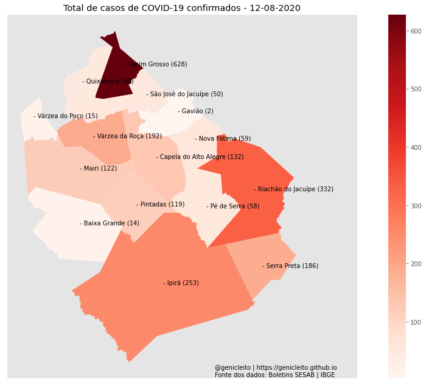

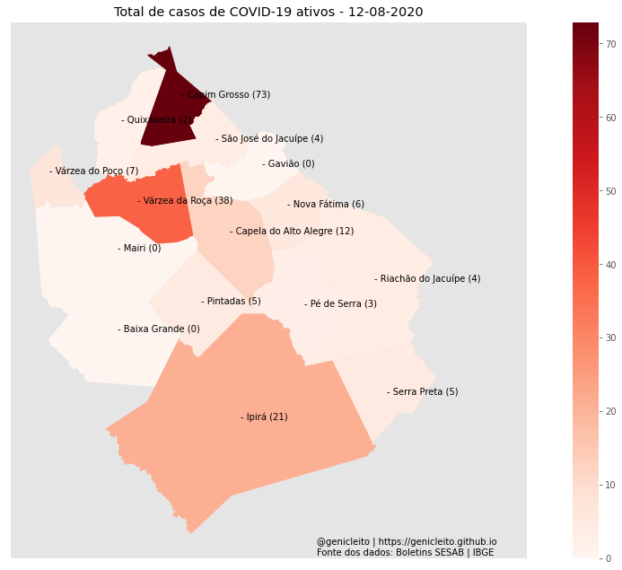

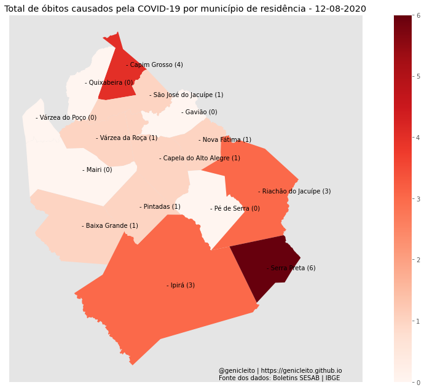

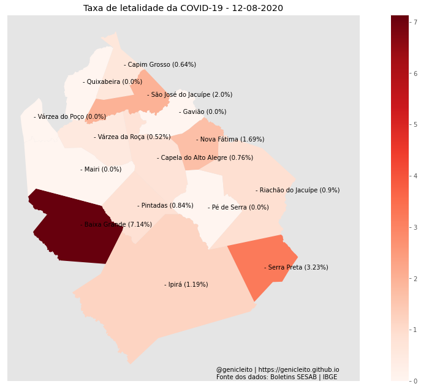

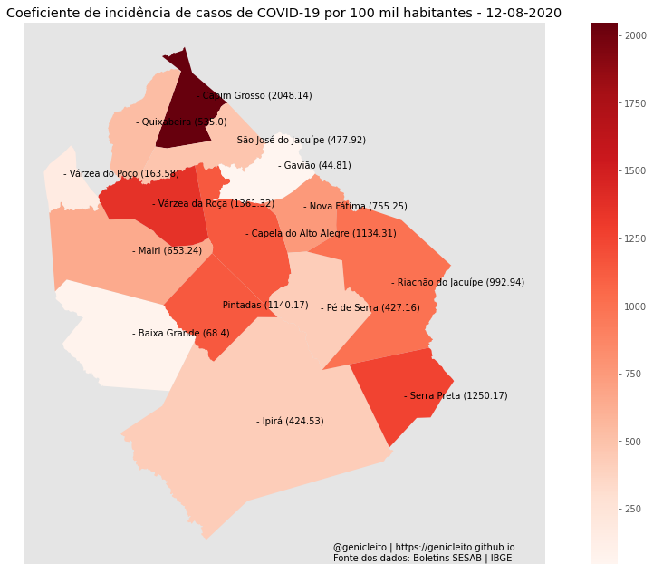

O coeficiente de incidência por 100 mil habitantes mede a incidência de casos de COVID-19 para cada 100 mil habitantes (obtido pela divisão do número de casos da localidade pela população vezes 100 mil).

Esse é uma forma mais justa de comparação do número de casos dos territórios pois todos têm como referência 100 mil habitantes com relação à população real.

## 3. Dados históricos da COVID-19 na Bacia do Jacuípe

Topo da página

### 3.1 Dados históricos

Gráfico com os dados históricos de COVID-19 da Bacia do Jacuípe

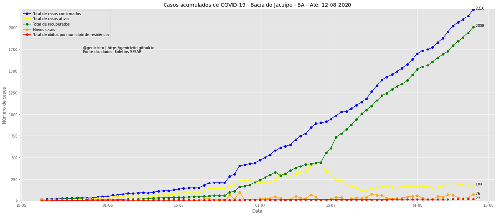

Tabela com medidas dos dados históricos de COVID-19 da Bacia do Jacuípe

|  | Confirmados | Casos ativos | Recuperados | Óbitos por município de residência | Novos Casos | Novos óbitos |
| --- | --- | --- | --- | --- | --- | --- |
| Mediana | 456 | 153 | 229 | 10 | 20 | 0 |
| Máximo | 2210 | 443 | 2008 | 22 | 99 | 3 |

Situação atual do número de casos de coronavírus

|  | Situação da COVID-19 na Bacia do Jacuípe na data 12-08-2020 |
| --- | --- |
| Confirmados | 2210 |
| Casos ativos | 180 |
| Recuperados | 2008 |
| Óbitos por município de residência | 22 |
| Novos Casos | 76 |
| Novos óbitos | 0 |

### 3.2 Informações dos dados acumulados por cidade

Topo da página

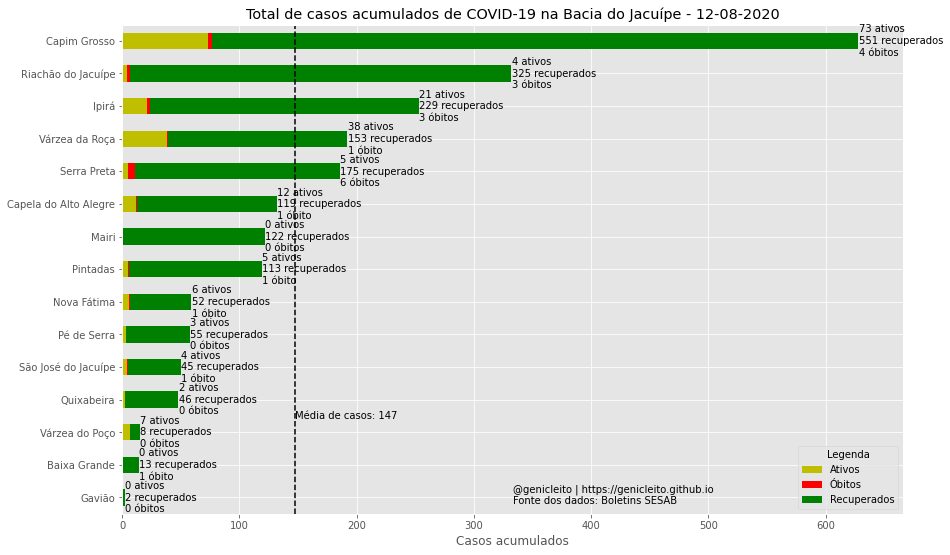

## 4. Dados históricos da COVID-19 por cidade

Topo da página

Abaixo são exibidos os dados históricos agregados (acumulados ao longo do tempo, a partir da data 19-05-2020 até a data atual) dos municípios que compõem a Bacia do Jacuípe. Para as datas em que não foi possível extrair os dados do boletim da SESAB (por inconsistência do arquivo ou algo do tipo) foram repetidos os dados da data anterior.

Abaixo dos gráficos, para cada município, há uma tabela com os valores de **mediana** e **máximo** para os `novos casos`, `casos confirmados`, `casos ativos`, `casos recuperados`, `óbitos por município de residência` e `novos óbitos`.

```
Dados históricos da COVID-19 no município de Baixa Grande
```

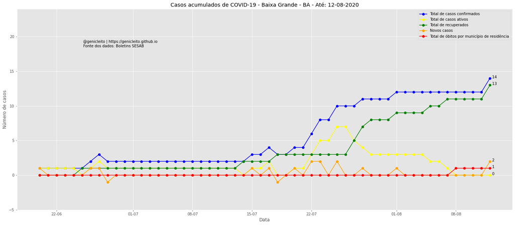

```
Tabela com medidas dos dados históricos da COVID-19 em Baixa Grande
```

|  | Confirmados | Casos ativos | Recuperados | Óbito por município de residência | Novos casos |
| --- | --- | --- | --- | --- | --- |
| Mediana | 3 | 1 | 2 | 0 | 0 |
| Máximo | 14 | 7 | 13 | 1 | 2 |

```
Dados históricos da COVID-19 no município de Capela do Alto Alegre
```

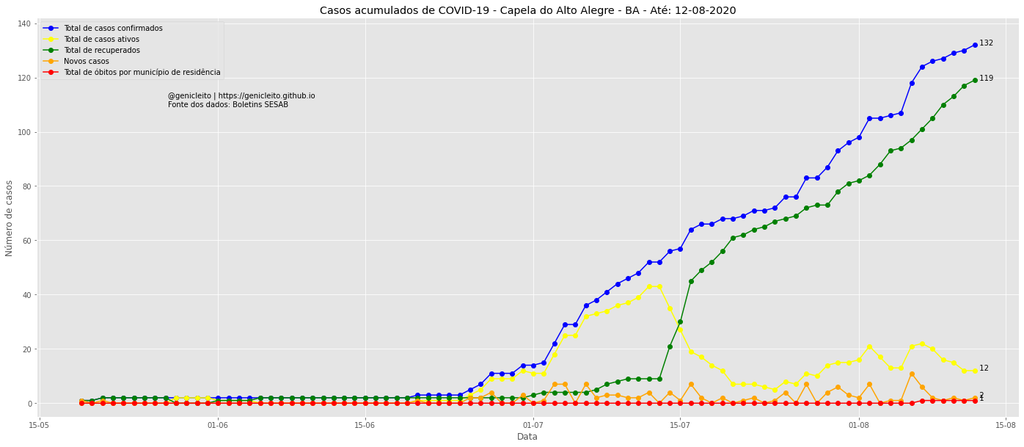

```
Tabela com medidas dos dados históricos da COVID-19 em Capela do Alto Alegre
```

|  | Confirmados | Casos ativos | Recuperados | Óbito por município de residência | Novos casos |
| --- | --- | --- | --- | --- | --- |
| Mediana | 14 | 7 | 2 | 0 | 0 |
| Máximo | 132 | 43 | 119 | 1 | 11 |

```
Dados históricos da COVID-19 no município de Capim Grosso
```

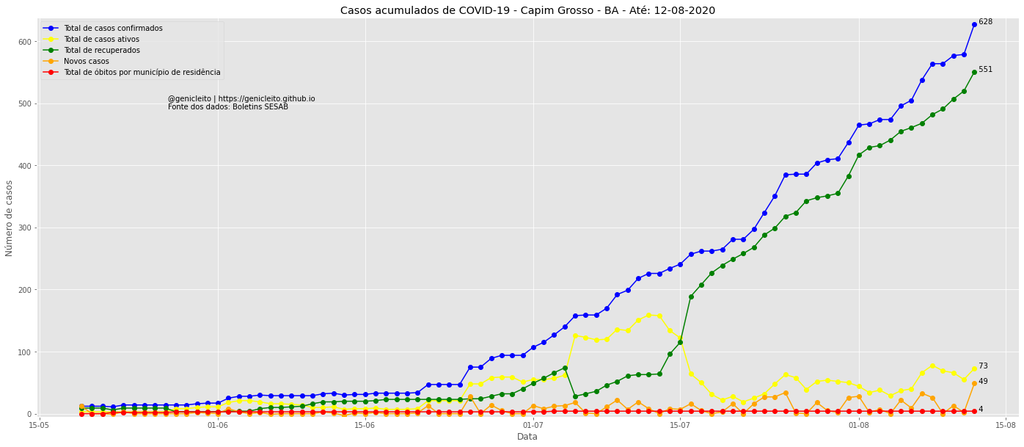

```
Tabela com medidas dos dados históricos da COVID-19 em Capim Grosso
```

|  | Confirmados | Casos ativos | Recuperados | Óbito por município de residência | Novos casos |
| --- | --- | --- | --- | --- | --- |
| Mediana | 100 | 31 | 32 | 3 | 2 |
| Máximo | 628 | 159 | 551 | 4 | 49 |

```
Dados históricos da COVID-19 no município de Gavião
```

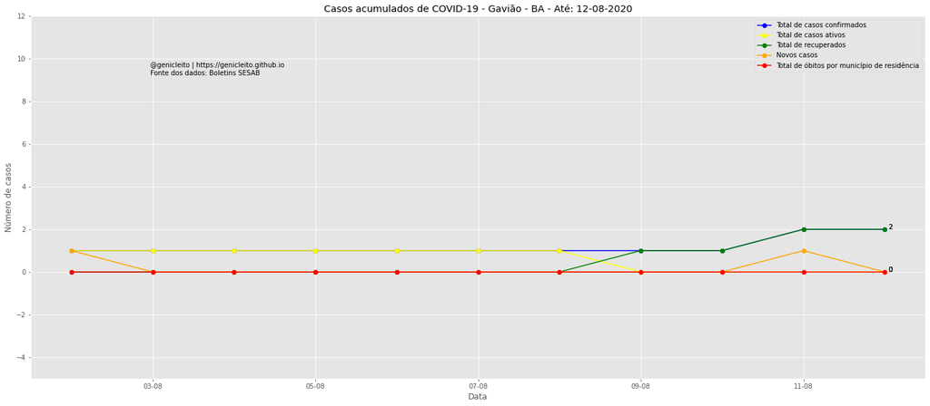

```
Tabela com medidas dos dados históricos da COVID-19 em Gavião
```

|  | Confirmados | Casos ativos | Recuperados | Óbito por município de residência | Novos casos |
| --- | --- | --- | --- | --- | --- |
| Mediana | 1 | 1 | 0 | 0 | 0 |
| Máximo | 2 | 1 | 2 | 0 | 1 |

```
Dados históricos da COVID-19 no município de Ipirá
```

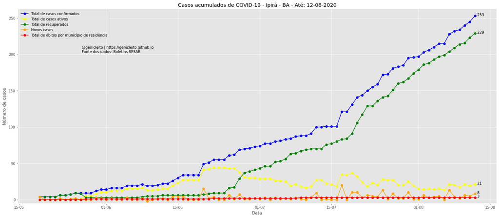

```
Tabela com medidas dos dados históricos da COVID-19 em Ipirá
```

|  | Confirmados | Casos ativos | Recuperados | Óbito por município de residência | Novos casos |
| --- | --- | --- | --- | --- | --- |
| Mediana | 73 | 20 | 42 | 2 | 2 |
| Máximo | 253 | 44 | 229 | 3 | 20 |

```
Dados históricos da COVID-19 no município de Mairi
```

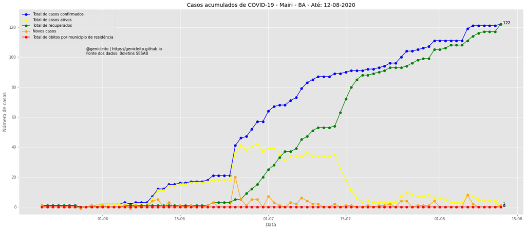

```
Tabela com medidas dos dados históricos da COVID-19 em Mairi
```

|  | Confirmados | Casos ativos | Recuperados | Óbito por município de residência | Novos casos |
| --- | --- | --- | --- | --- | --- |
| Mediana | 65 | 7 | 26 | 0 | 0 |
| Máximo | 122 | 42 | 122 | 0 | 20 |

```
Dados históricos da COVID-19 no município de Nova Fátima
```

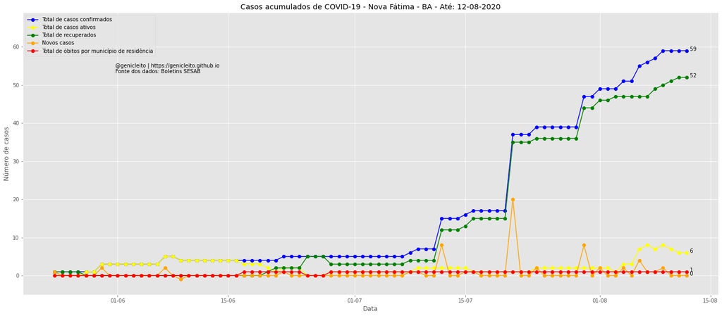

```
Tabela com medidas dos dados históricos da COVID-19 em Nova Fátima
```

|  | Confirmados | Casos ativos | Recuperados | Óbito por município de residência | Novos casos |
| --- | --- | --- | --- | --- | --- |
| Mediana | 5 | 2 | 3 | 1 | 0 |
| Máximo | 59 | 8 | 52 | 1 | 20 |

```
Dados históricos da COVID-19 no município de Pintadas
```

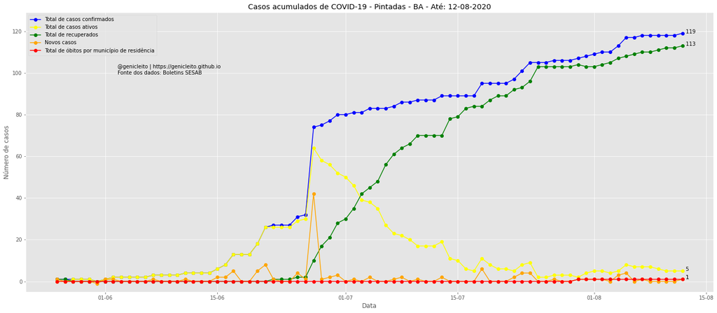

```
Tabela com medidas dos dados históricos da COVID-19 em Pintadas
```

|  | Confirmados | Casos ativos | Recuperados | Óbito por município de residência | Novos casos |
| --- | --- | --- | --- | --- | --- |
| Mediana | 83 | 6 | 45 | 0 | 0 |
| Máximo | 119 | 64 | 113 | 1 | 42 |

```
Dados históricos da COVID-19 no município de Pé de Serra
```

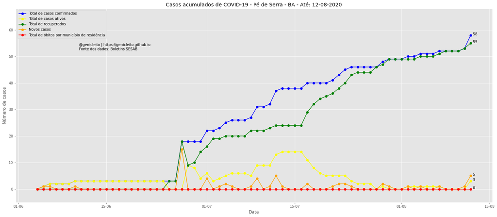

```
Tabela com medidas dos dados históricos da COVID-19 em Pé de Serra
```

|  | Confirmados | Casos ativos | Recuperados | Óbito por município de residência | Novos casos |
| --- | --- | --- | --- | --- | --- |
| Mediana | 29 | 3 | 22 | 0 | 0 |
| Máximo | 58 | 14 | 55 | 0 | 15 |

```
Dados históricos da COVID-19 no município de Quixabeira
```

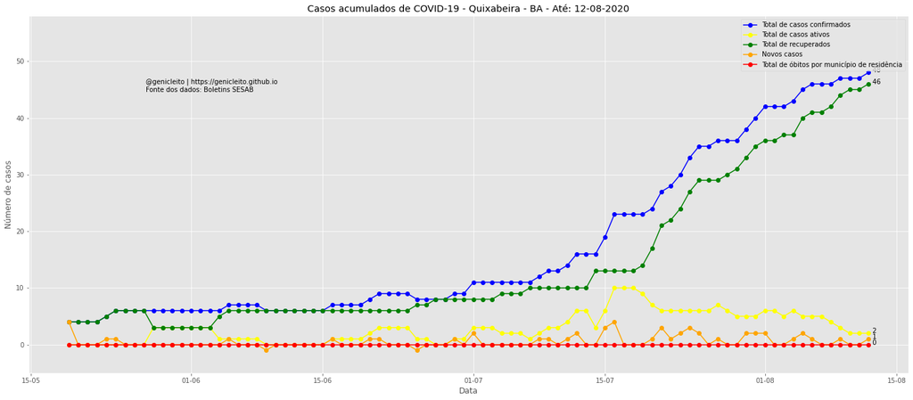

```
Tabela com medidas dos dados históricos da COVID-19 em Quixabeira
```

|  | Confirmados | Casos ativos | Recuperados | Óbito por município de residência | Novos casos |
| --- | --- | --- | --- | --- | --- |
| Mediana | 10 | 3 | 8 | 0 | 0 |
| Máximo | 48 | 10 | 46 | 0 | 4 |

```
Dados históricos da COVID-19 no município de Riachão do Jacuípe
```

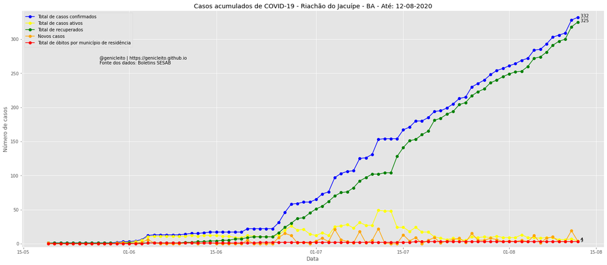

```
Tabela com medidas dos dados históricos da COVID-19 em Riachão do Jacuípe
```

|  | Confirmados | Casos ativos | Recuperados | Óbito por município de residência | Novos casos |
| --- | --- | --- | --- | --- | --- |
| Mediana | 63 | 10 | 48 | 2 | 1 |
| Máximo | 332 | 49 | 325 | 3 | 22 |

```
Dados históricos da COVID-19 no município de Serra Preta
```

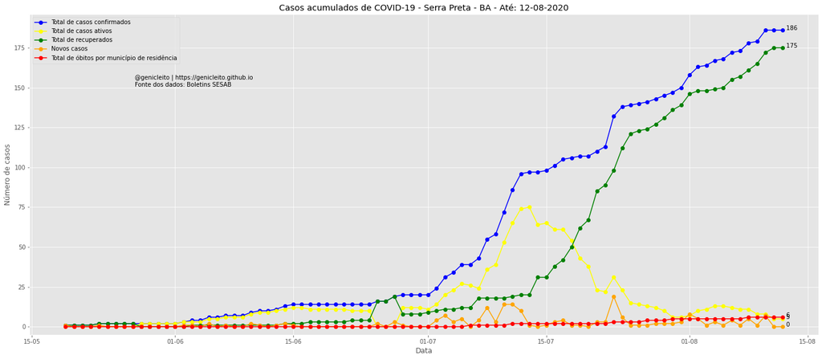

```
Tabela com medidas dos dados históricos da COVID-19 em Serra Preta
```

|  | Confirmados | Casos ativos | Recuperados | Óbito por município de residência | Novos casos |
| --- | --- | --- | --- | --- | --- |
| Mediana | 20 | 11 | 11 | 0 | 1 |
| Máximo | 186 | 75 | 175 | 6 | 19 |

```
Dados históricos da COVID-19 no município de São José do Jacuípe
```

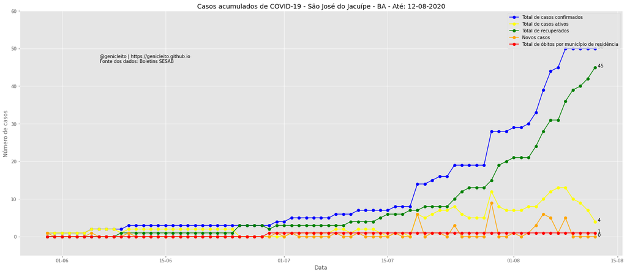

```
Tabela com medidas dos dados históricos da COVID-19 em São José do Jacuípe
```

|  | Confirmados | Casos ativos | Recuperados | Óbito por município de residência | Novos casos |
| --- | --- | --- | --- | --- | --- |
| Mediana | 5 | 2 | 3 | 1 | 0 |
| Máximo | 50 | 13 | 45 | 1 | 9 |

```
Dados históricos da COVID-19 no município de Várzea da Roça
```

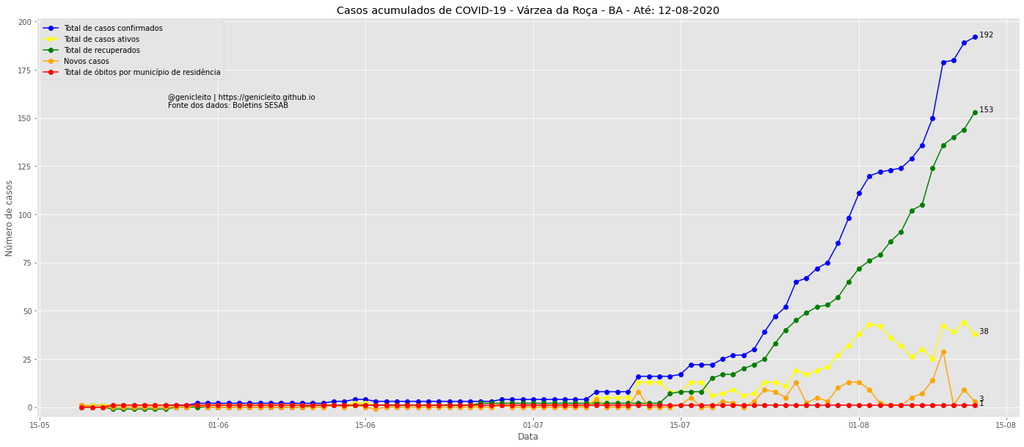

```
Tabela com medidas dos dados históricos da COVID-19 em Várzea da Roça
```

|  | Confirmados | Casos ativos | Recuperados | Óbito por município de residência | Novos casos |
| --- | --- | --- | --- | --- | --- |
| Mediana | 4 | 1 | 2 | 1 | 0 |
| Máximo | 192 | 44 | 153 | 1 | 29 |

```
Dados históricos da COVID-19 no município de Várzea do Poço
```

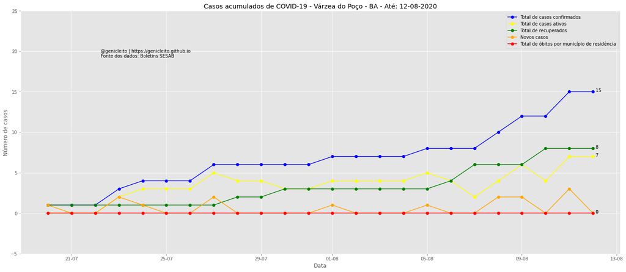

```
Tabela com medidas dos dados históricos da COVID-19 em Várzea do Poço
```

|  | Confirmados | Casos ativos | Recuperados | Óbito por município de residência | Novos casos |
| --- | --- | --- | --- | --- | --- |
| Mediana | 6 | 4 | 3 | 0 | 0 |
| Máximo | 15 | 7 | 8 | 0 | 3 |

### Fontes consultadas

- **SESAB** - Notas Técnicas e Boletins Epidemiológicos – Covid-19: http://www.saude.ba.gov.br/temasdesaude/coronavirus/notas-tecnicas-e-boletins-epidemiologicos-covid-19/
- **IBGE** - Bases Cartográficas - Malhas digitais: https://mapas.ibge.gov.br/bases-e-referenciais/bases-cartograficas/malhas-digitais

Documento produzido por **Genicleito Gonçalves**

Caso identifique alguma inconsistência enviar email para: genicleito@live.com

Redes sociais:

- Site: https://genicleito.github.io
- Instagram: https://www.instagram.com/genicleito/
- Twitter: https://twitter.com/genicleito
- Facebook: https://fb.com/genicleito
- GitHub: https://github.com/genicleito